# 8.3HW

## 8E4. Explain the difference between the effective number of samples, n_eff as calculated by Stan, and the actual number of samples.

The effective number of samples are the minimum number of samples needed for the MCMC to predict the shape of the posterior.

## 8E5 Which value should Rhat approach, when a chain is sampling the posterior distribution cor- rectly?

1 even 1.02 is considered a bad sampling.

## 8E6 Sketch a good trace plot for a Markov chain,one that is effectively sampling from th eposterior distribution. What is good about its shape? Then sketch a trace plot for a malfunctioning Markov chain. What about its shape indicates malfunction?

A good plot should be centered around a mean and remain centered around the same mean durring the adaptation and after adapting to the posterior, remaining stationary. The trace should also show that sampling from a variety of parameters

## 8M1. Re-estimate the terrain ruggedness model from the chapter,but now using a uniform prior and an exponential prior for the standard deviation, sigma. The uniform prior should be dunif(0,10) and the exponential should be dexp(1). Do the different priors have any detectible influence on the posterior distribution?

# uniform prior

```r
library(rethinking)
data(rugged)
d <- rugged
d$log_gdp <- log(d$rgdppc_2000)
dd <- d[ complete.cases(d$rgdppc_2000) , ]

dd.trim <- dd[ , c("log_gdp","rugged","cont_africa") ]
str(dd.trim)
```

```
## 'data.frame':    170 obs. of  3 variables:
##  $ log_gdp    : num  7.49 8.22 9.93 9.41 7.79 ...
##  $ rugged     : num  0.858 3.427 0.769 0.775 2.688 ...
##  $ cont_africa: int  1 0 0 0 0 0 0 0 0 1 ...
```

```r
m8.1stan <- map2stan(
    alist(
        log_gdp ~ dnorm( mu , sigma ) ,
        mu <- a + bR*rugged + bA*cont_africa + bAR*rugged*cont_africa ,
        a ~ dnorm(0,100),
        bR ~ dnorm(0,10),
        bA ~ dnorm(0,10),
        bAR ~ dnorm(0,10),
        sigma ~ dcauchy(0,2)
), data=dd.trim )
```

[output not shown]

```
## Computing WAIC
```

```
## Constructing posterior predictions
```

```
## [ 100 / 1000 ]
[ 200 / 1000 ]
[ 300 / 1000 ]
[ 400 / 1000 ]
[ 500 / 1000 ]
[ 600 / 1000 ]
[ 700 / 1000 ]
[ 800 / 1000 ]
[ 900 / 1000 ]
[ 1000 / 1000 ]
```

```r
m8.2stan <- map2stan(
    alist(
        log_gdp ~ dnorm( mu , sigma ) ,
        mu <- a + bR*rugged + bA*cont_africa + bAR*rugged*cont_africa ,
        a ~ dnorm(0,100),
        bR ~ dnorm(0,10),
        bA ~ dnorm(0,10),
        bAR ~ dnorm(0,10),
        sigma ~ dunif(0,10)
), data=dd.trim )
```

[output not shown]

```
## Computing WAIC
## Constructing posterior predictions
```

```
## [ 100 / 1000 ]
[ 200 / 1000 ]
[ 300 / 1000 ]
[ 400 / 1000 ]
[ 500 / 1000 ]
[ 600 / 1000 ]
[ 700 / 1000 ]
[ 800 / 1000 ]
[ 900 / 1000 ]
[ 1000 / 1000 ]
```

```r
precis(m8.2stan)
```

```
##        Mean StdDev lower 0.89 upper 0.89 n_eff Rhat
## a      9.21   0.14       8.99       9.44   333    1
## bR    -0.20   0.08      -0.34      -0.09   327    1
## bA    -1.94   0.23      -2.34      -1.60   367    1
## bAR    0.39   0.14       0.18       0.61   355    1
## sigma  0.95   0.05       0.86       1.03   774    1
```

## exponential prior

```r
m8.3stan <- map2stan(
    alist(
        log_gdp ~ dnorm( mu , sigma ) ,
        mu <- a + bR*rugged + bA*cont_africa + bAR*rugged*cont_africa ,
        a ~ dnorm(0,100),
        bR ~ dnorm(0,10),
        bA ~ dnorm(0,10),
        bAR ~ dnorm(0,10),
        sigma ~ dexp(1)
), data=dd.trim )
```

[output not shown]

```
## Computing WAIC
```

```
## Constructing posterior predictions
```

```
## [ 100 / 1000 ]
[ 200 / 1000 ]
[ 300 / 1000 ]
[ 400 / 1000 ]
[ 500 / 1000 ]
[ 600 / 1000 ]
[ 700 / 1000 ]
[ 800 / 1000 ]
[ 900 / 1000 ]
[ 1000 / 1000 ]
```

```r
precis(m8.3stan)
```

```
##        Mean StdDev lower 0.89 upper 0.89 n_eff Rhat
## a      9.22   0.14       9.00       9.44   348    1
## bR    -0.20   0.08      -0.31      -0.07   351    1
## bA    -1.95   0.23      -2.35      -1.62   359    1
## bAR    0.40   0.13       0.20       0.61   412    1
## sigma  0.95   0.05       0.87       1.03   770    1
```

## The Cauchy and exponential priors from the terrain ruggedness model are very weak. They can be made more informative by reducing their scale. Compare the dcauchy and dexp priors for progressively smaller values of the scaling parameter. As these priors become stronger, how does each influence the posterior distribution?

```r
m8.4stan <- map2stan(
    alist(
        log_gdp ~ dnorm( mu , sigma ) ,
        mu <- a + bR*rugged + bA*cont_africa + bAR*rugged*cont_africa ,
        a ~ dnorm(0,100),
        bR ~ dnorm(0,10),
        bA ~ dnorm(0,10),
        bAR ~ dnorm(0,10),
        sigma ~ dexp(.2)
), data=dd.trim )
```

[output not shown]

```
## Computing WAIC
```

```
## Constructing posterior predictions
```

```
## [ 100 / 1000 ]
[ 200 / 1000 ]
[ 300 / 1000 ]
[ 400 / 1000 ]
[ 500 / 1000 ]
[ 600 / 1000 ]
[ 700 / 1000 ]
[ 800 / 1000 ]
[ 900 / 1000 ]
[ 1000 / 1000 ]
```

```r
m8.5stan <- map2stan(
    alist(
        log_gdp ~ dnorm( mu , sigma ) ,
        mu <- a + bR*rugged + bA*cont_africa + bAR*rugged*cont_africa ,
        a ~ dnorm(0,100),
        bR ~ dnorm(0,10),
        bA ~ dnorm(0,10),
        bAR ~ dnorm(0,10),
        sigma ~ dcauchy(0,1)
), data=dd.trim )
```

[output not shown]

```
## Computing WAIC
## Constructing posterior predictions
```

```
## [ 100 / 1000 ]
[ 200 / 1000 ]
[ 300 / 1000 ]
[ 400 / 1000 ]
[ 500 / 1000 ]
[ 600 / 1000 ]
[ 700 / 1000 ]
[ 800 / 1000 ]
[ 900 / 1000 ]
[ 1000 / 1000 ]
```

```r
m8.6stan <- map2stan(
    alist(
        log_gdp ~ dnorm( mu , sigma ) ,
        mu <- a + bR*rugged + bA*cont_africa + bAR*rugged*cont_africa ,
        a ~ dnorm(0,100),
        bR ~ dnorm(0,10),
        bA ~ dnorm(0,10),
        bAR ~ dnorm(0,10),
        sigma ~ dcauchy(0,100)
), data=dd.trim )
```

[output not shown]

```
## Computing WAIC
## Constructing posterior predictions
```

```
## [ 100 / 1000 ]
[ 200 / 1000 ]
[ 300 / 1000 ]
[ 400 / 1000 ]
[ 500 / 1000 ]
[ 600 / 1000 ]
[ 700 / 1000 ]
[ 800 / 1000 ]
[ 900 / 1000 ]
[ 1000 / 1000 ]
```

```r
precis(m8.4stan)
```

```
##        Mean StdDev lower 0.89 upper 0.89 n_eff Rhat
## a      9.23   0.14       9.00       9.42   254    1
## bR    -0.21   0.08      -0.33      -0.10   219    1
## bA    -1.96   0.21      -2.31      -1.63   237    1
## bAR    0.40   0.12       0.19       0.58   437    1
## sigma  0.95   0.05       0.87       1.03   654    1
```

```r
precis(m8.5stan)
```

```
##        Mean StdDev lower 0.89 upper 0.89 n_eff Rhat
## a      9.23   0.15       8.98       9.45   311    1
## bR    -0.21   0.08      -0.34      -0.09   361    1
## bA    -1.95   0.24      -2.32      -1.58   326    1
## bAR    0.39   0.13       0.18       0.58   408    1
## sigma  0.95   0.05       0.88       1.03   724    1
```

```r
precis(m8.1stan)
```

```
##        Mean StdDev lower 0.89 upper 0.89 n_eff Rhat
## a      9.22   0.13       9.01       9.43   368 1.00
## bR    -0.20   0.07      -0.32      -0.09   372 1.00
## bA    -1.95   0.22      -2.26      -1.58   304 1.02
## bAR    0.39   0.13       0.18       0.59   353 1.01
## sigma  0.95   0.05       0.86       1.02   494 1.01
```

```r
precis(m8.6stan)
```

```
##        Mean StdDev lower 0.89 upper 0.89 n_eff Rhat
## a      9.22   0.14       9.02       9.45   314 1.00
## bR    -0.20   0.08      -0.31      -0.07   275 1.00
## bA    -1.94   0.22      -2.28      -1.58   401 1.00
## bAR    0.39   0.13       0.17       0.57   335 1.00
## sigma  0.95   0.05       0.87       1.02   636 1.01
```

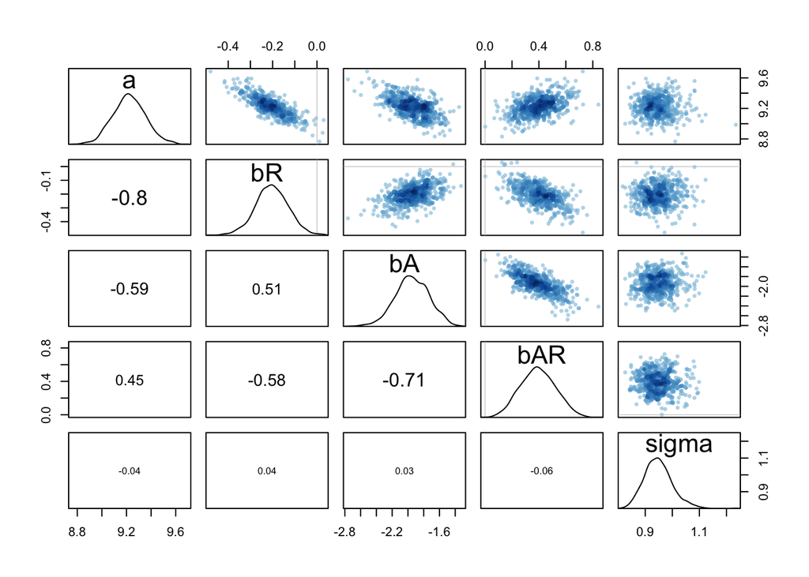

```r
pairs(m8.1stan)
```

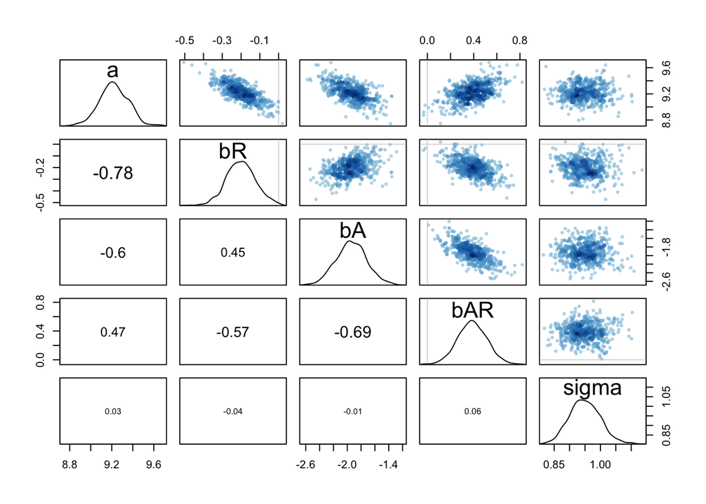

```r
pairs(m8.6stan)
```

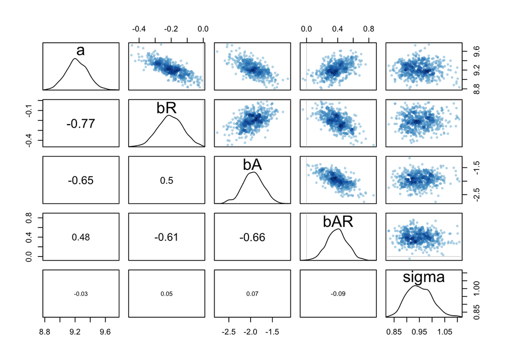

```r
pairs(m8.5stan)
```

## 8M3. Re-estimate one of the Stan models from the chapter, but at different numbers of warmup iterations. Be sure to use the same number of sampling iterations in each case. Compare the n_eff values. How much warmup is enough?

larger variance but the n_eff goes down with smaller warm up numbers

```r
m8.7stan <- map2stan(
    alist(
        log_gdp ~ dnorm( mu , sigma ) ,
        mu <- a + bR*rugged + bA*cont_africa + bAR*rugged*cont_africa ,
        a ~ dnorm(0,100),
        bR ~ dnorm(0,10),
        bA ~ dnorm(0,10),
        bAR ~ dnorm(0,10),
        sigma ~ dcauchy(0,1)
), data=dd.trim, chains=1 , iter=4000 , warmup=1000 )
```

[output not shown]

```
## Computing WAIC
```

```
## Constructing posterior predictions
```

```
## [ 300 / 3000 ]
[ 600 / 3000 ]
[ 900 / 3000 ]
[ 1200 / 3000 ]
[ 1500 / 3000 ]
[ 1800 / 3000 ]
[ 2100 / 3000 ]
[ 2400 / 3000 ]
[ 2700 / 3000 ]
[ 3000 / 3000 ]
```

```r
m8.8stan <- map2stan(
    alist(
        log_gdp ~ dnorm( mu , sigma ) ,
        mu <- a + bR*rugged + bA*cont_africa + bAR*rugged*cont_africa ,
        a ~ dnorm(0,100),
        bR ~ dnorm(0,10),
        bA ~ dnorm(0,10),
        bAR ~ dnorm(0,10),
        sigma ~ dcauchy(0,1)
), data=dd.trim, chains=1 , iter=4000 , warmup=25 )
```

[output not shown]

```
## Computing WAIC
## Constructing posterior predictions
```

```
## [ 397 / 3975 ]
[ 794 / 3975 ]
[ 1191 / 3975 ]
[ 1588 / 3975 ]
[ 1985 / 3975 ]
[ 2382 / 3975 ]
[ 2779 / 3975 ]
[ 3176 / 3975 ]
[ 3573 / 3975 ]
[ 3970 / 3975 ]
[ 3975 / 3975 ]
```

```r
precis(m8.7stan)
```

```
##        Mean StdDev lower 0.89 upper 0.89 n_eff Rhat
## a      9.22   0.14       9.01       9.44  1121    1
## bR    -0.20   0.07      -0.32      -0.08  1200    1
## bA    -1.95   0.22      -2.31      -1.62  1130    1
## bAR    0.40   0.13       0.20       0.59  1202    1
## sigma  0.95   0.05       0.87       1.03  2297    1
```

```r
precis(m8.8stan)
```

[output not shown]